# 📧 SPAM OR HAM 📧

**📑 TABLE OF CONTENTS 📑**

* 📚 IMPORTING LIBRARIES  
* 🗂 LOADING DATA  
* * 📊 🔎DATA EXPLORATION  
* 🔍 OUTLIER DETECTION  
* * 🧹 🔎DATA PREPROCESSING * ✨ CLEANING TEXT  
* ✂️ TOKENIZATION  
* 🚫 REMOVING STOPWORDS  
* 🧩 LEMMATIZATION  
* 🔠 VECTORIZATION  
* 🏗 MODEL BUILDING  
* 📈 EVALUATING MODELS  
* 🏁 END

### 📚 Importing Libraries 📚

```python
#Importing all the libraries to be used
import warnings
import re
import nltk
import matplotlib.pyplot as plt
import seaborn as sns
import numpy as np
import pandas as pd
from nltk.corpus import stopwords
from nltk.stem.porter import PorterStemmer
from nltk.stem import WordNetLemmatizer
from sklearn.feature_extraction.text import TfidfVectorizer
from sklearn.preprocessing import LabelEncoder
from sklearn.model_selection import train_test_split
from sklearn.pipeline import Pipeline
from sklearn.naive_bayes import MultinomialNB
from sklearn.ensemble import RandomForestClassifier
from sklearn.neighbors import KNeighborsClassifier
from sklearn.svm import SVC
from sklearn.model_selection import cross_val_score
from matplotlib.colors import ListedColormap
from sklearn.metrics import precision_score, recall_score, confusion_matrix, classification_report, accuracy_score, f1_score
from sklearn import metrics
```

### 📊 Loading Data

```python
#Loading data
data = pd.read_csv(r"C:\Users\acer\Downloads\spam.csv", encoding='ISO-8859-1')
data.info()
```

```
<class 'pandas.core.frame.DataFrame'>
RangeIndex: 5572 entries, 0 to 5571
Data columns (total 5 columns):
 #   Column      Non-Null Count  Dtype
---  ------      --------------  -----
 0   v1          5572 non-null   object
 1   v2          5572 non-null   object
 2   Unnamed: 2  50 non-null     object
 3   Unnamed: 3  12 non-null     object
 4   Unnamed: 4  6 non-null      object
dtypes: object(5)
memory usage: 217.8+ KB
```

```python
# Dropping the redundent looking collumns (for this project)
to_drop = ["Unnamed: 2","Unnamed: 3","Unnamed: 4"]
data = data.drop(data[to_drop], axis=1)
# Renaming the columns because I feel fancy today
data.rename(columns = {"v1":"Target", "v2":"Text"}, inplace = True)
data.head()
```

|  | Target | Text |
| --- | --- | --- |
| 0 | ham | Go until jurong point, crazy.. Available only ... |
| 1 | ham | Ok lar... Joking wif u oni... |
| 2 | spam | Free entry in 2 a wkly comp to win FA Cup fina... |
| 3 | ham | U dun say so early hor... U c already then say... |
| 4 | ham | Nah I don't think he goes to usf, he lives aro... |

### 🌐 Data Exploration

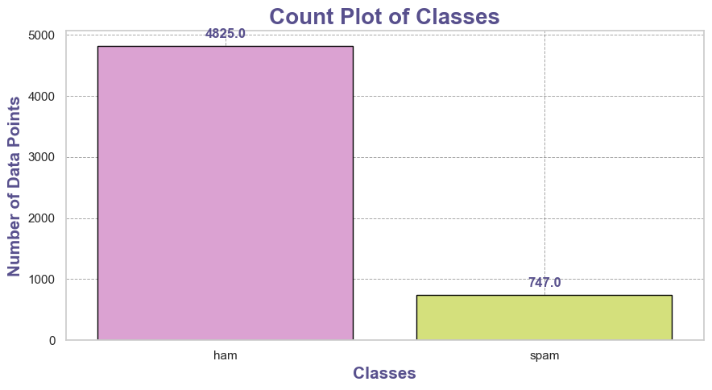

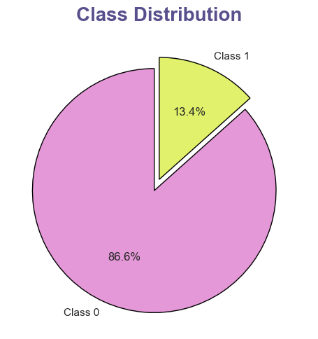

```python
#Custom style
sns.set(style="whitegrid")

# Palette
cols =[ "#E598D8", "#E1F16B"]

# Create the count plot
plt.figure(figsize=(9, 5))
fg = sns.countplot(x=data["Target"], palette=cols, edgecolor='black')

# Add title and labels with improved aesthetics
fg.set_title("Count Plot of Classes", color="#58508d", fontsize=20, fontweight='bold')
fg.set_xlabel("Classes", color="#58508d", fontsize=15, fontweight='bold')
fg.set_ylabel("Number of Data Points", color="#58508d", fontsize=15, fontweight='bold')

# Add annotations on top of the bars
for p in fg.patches:
    height = p.get_height()
    fg.annotate(f'{height}', (p.get_x() + p.get_width() / 2., height),
                ha='center', va='center', xytext=(0, 10), textcoords='offset points',
                color="#58508d", fontsize=12, fontweight='bold')

# Add gridlines
plt.grid(True, which='both', linestyle='--', linewidth=0.7, color='gray', alpha=0.7)

# Show the count plot
plt.tight_layout()
plt.show()

# Create the pie chart
# Calculate the percentage of each class
class_counts = data['Target'].value_counts()
class_labels = class_counts.index
class_sizes = class_counts.values

# Create a pie chart
plt.figure(figsize=(9, 5))
plt.pie(class_sizes, labels=['Class 0', 'Class 1'], autopct='%1.1f%%', startangle=90,
        explode=(0.1, 0), colors=cols, wedgeprops={'edgecolor': 'black', 'linewidth': 1, 'antialiased': True})
plt.title('Class Distribution', color="#58508d", fontsize=20, fontweight='bold')

# Show the pie chart
plt.tight_layout()
plt.show()
```

**Note:** From the above countplot the data imbalance is quite evident.

For the purpose of data exploration, I am creating new features

- No_of_Characters: Number of characters in the text message
- No_of_Words: Number of words in the text message
- No_of_sentence: Number of sentences in the text message

```python
#Adding a column of numbers of charachters,words and sentences in each msg
data["No_of_Characters"] = data["Text"].apply(len)
data["No_of_Words"]=data.apply(lambda row: nltk.word_tokenize(row["Text"]), axis=1).apply(len)
data["No_of_sentence"]=data.apply(lambda row: nltk.sent_tokenize(row["Text"]), axis=1).apply(len)

data.describe().T
```

|  | count | mean | std | min | 25% | 50% | 75% | max |
| --- | --- | --- | --- | --- | --- | --- | --- | --- |
| No_of_Characters | 5572.0 | 80.118808 | 59.690841 | 2.0 | 36.0 | 61.0 | 121.0 | 910.0 |
| No_of_Words | 5572.0 | 18.698492 | 13.737477 | 1.0 | 9.0 | 15.0 | 27.0 | 220.0 |
| No_of_sentence | 5572.0 | 1.991565 | 1.501427 | 1.0 | 1.0 | 1.5 | 2.0 | 38.0 |

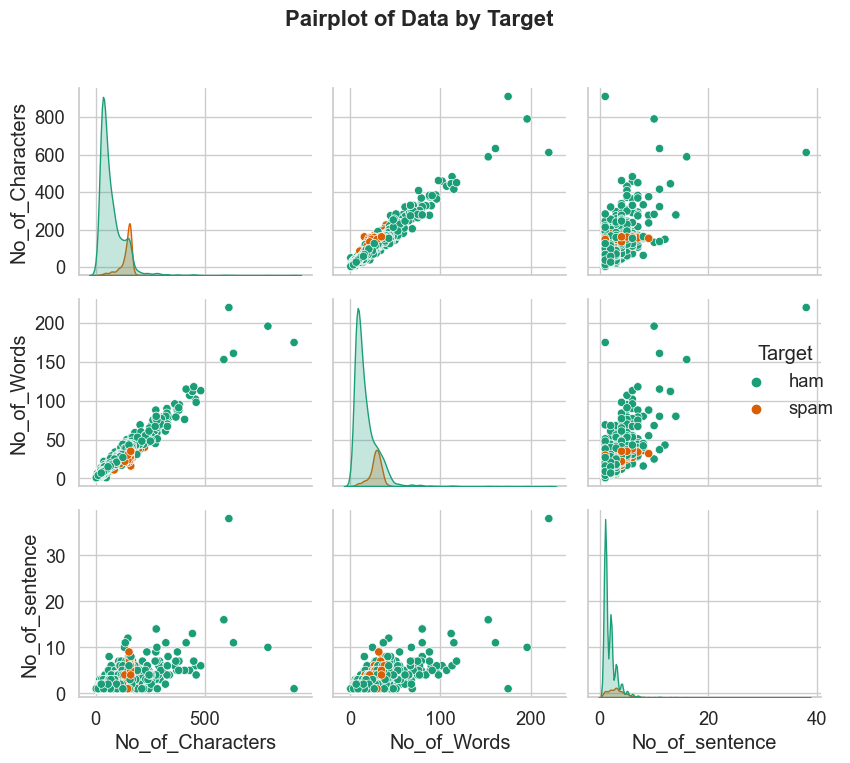

```python
plt.figure(figsize=(12, 8))
sns.set(font_scale=1.2)  # Adjust font scale if necessary
sns.set_style("whitegrid")  # Set a whitegrid background

dark_palette = sns.color_palette("Dark2", n_colors=len(data['Target'].unique()))
fg = sns.pairplot(data=data, hue="Target", palette=dark_palette)

# Customize labels and titles
fg.fig.suptitle('Pairplot of Data by Target', y=1.02, fontsize=16, fontweight='bold')  # Title with adjusted y position

plt.tight_layout()  # Adjust layout for better spacing
plt.show()
```

**Note:** From the pair plot, we can see a few outliers all in the class ham. This is interesting as we could put a cap over one of these. As they essentially indicate the same thing ie the length of SMS.

Next, I shall be dropping the outliers

```python
# Function to detect outliers using IQR
def outlier_detect(data, col):
    Q1 = data[col].quantile(0.25)
    Q3 = data[col].quantile(0.75)
    IQR = Q3 - Q1
    return data[(data[col] < Q1 - 1.5 * IQR) | (data[col] > Q3 + 1.5 * IQR)]

# Function to detect outliers using Z-score
def outlier_detect_normal(data, col):
    mean = data[col].mean()
    std = data[col].std()
    threshold = 3
    return data[(data[col] - mean).abs() > threshold * std]

# Function to detect categorical outliers
def outlier_detect_categorical(data, col):
    # Example logic for categorical outlier detection
    return data[data[col].str.contains('outlier')]

# Example usage for outlier detection
continuous_values = data.select_dtypes(include=['float64', 'int64']).columns.tolist()
for col in continuous_values:
    try:
        print("IQR Outliers for {}: {}".format(col, outlier_detect(data, col).shape[0]))
        print("Z-score Outliers for {}: {}".format(col, outlier_detect_normal(data, col).shape[0]))
        print("********************************")
    except KeyError as e:
        print(f"KeyError: Column '{col}' not found in data.")
        continue
```

```
IQR Outliers for No_of_Characters: 68
Z-score Outliers for No_of_Characters: 64
IQR Outliers for No_of_Words: 78
Z-score Outliers for No_of_Words: 67
IQR Outliers for No_of_sentence: 662
Z-score Outliers for No_of_sentence: 77
```

```python
#Dropping the outliers.
data = data[(data["No_of_Characters"]<350)]
data.shape
```

```
(5548, 5)
```

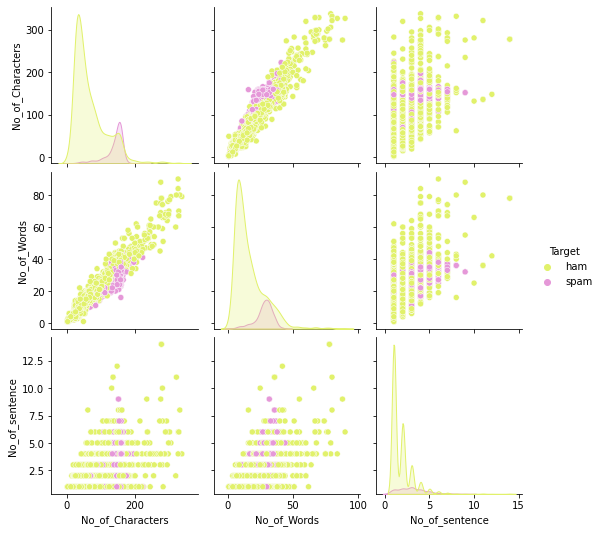

```python
plt.figure(figsize=(12,8))
fg = sns.pairplot(data=data, hue="Target",palette=cols)
plt.show(fg)
```

# CLEANING TEXT

To further process the data we need to make the data cleaner.

- In the first step we extract only the alphabetic characters by this we are removing punctuation and numbers.
- In the next step, we are converting all the characters into lowercase.

This text will be then used in further procrssing

```python
#Lets have a look at a sample of texts before cleaning
print("\033[1m\u001b[45;1m The First 5 Texts:\033[0m",*data["Text"][:5], sep = "\n")
```

```
 The First 5 Texts:
Go until jurong point, crazy.. Available only in bugis n great world la e buffet... Cine there got amore wat...
Ok lar... Joking wif u oni...
Free entry in 2 a wkly comp to win FA Cup final tkts 21st May 2005. Text FA to 87121 to receive entry question(std txt rate)T&C's apply 08452810075over18's
U dun say so early hor... U c already then say...
Nah I don't think he goes to usf, he lives around here though
```

```python
# Defining a function to clean up the text
def Clean(Text):
    sms = re.sub('[^a-zA-Z]', ' ', Text) #Replacing all non-alphabetic characters with a space
    sms = sms.lower() #converting to lowecase
    sms = sms.split()
    sms = ' '.join(sms)
    return sms

data["Clean_Text"] = data["Text"].apply(Clean)
#Lets have a look at a sample of texts after cleaning
print("\033[1m\u001b[45;1m The First 5 Texts after cleaning:\033[0m",*data["Clean_Text"][:5], sep = "\n")
```

```
 The First 5 Texts after cleaning:
go until jurong point crazy available only in bugis n great world la e buffet cine there got amore wat
ok lar joking wif u oni
free entry in a wkly comp to win fa cup final tkts st may text fa to to receive entry question std txt rate t c s apply over s
u dun say so early hor u c already then say
nah i don t think he goes to usf he lives around here though
```

# TOKENIZATION

**Tokenization** is breaking complex data into smaller units called tokens. It can be done by splitting paragraphs into sentences and sentences into words. I am splitting the Clean_Text into words at this step.

```python
data["Tokenize_Text"]=data.apply(lambda row: nltk.word_tokenize(row["Clean_Text"]), axis=1)

print("\033[1m\u001b[45;1m The First 5 Texts after Tokenizing:\033[0m",*data["Tokenize_Text"][:5], sep = "\n")
```

```
 The First 5 Texts after Tokenizing:
['go', 'until', 'jurong', 'point', 'crazy', 'available', 'only', 'in', 'bugis', 'n', 'great', 'world', 'la', 'e', 'buffet', 'cine', 'there', 'got', 'amore', 'wat']
['ok', 'lar', 'joking', 'wif', 'u', 'oni']
['free', 'entry', 'in', 'a', 'wkly', 'comp', 'to', 'win', 'fa', 'cup', 'final', 'tkts', 'st', 'may', 'text', 'fa', 'to', 'to', 'receive', 'entry', 'question', 'std', 'txt', 'rate', 't', 'c', 's', 'apply', 'over', 's']
['u', 'dun', 'say', 'so', 'early', 'hor', 'u', 'c', 'already', 'then', 'say']
['nah', 'i', 'don', 't', 'think', 'he', 'goes', 'to', 'usf', 'he', 'lives', 'around', 'here', 'though']
```

# REMOVING STOPWORDS

**Stopwords** are frequently occurring words(*such as few, is, an, etc*). These words hold meaning in sentence structure, but do not contribute much to language processing in NLP. For the purpose of removing redundancy in our processing, I am removing those. NLTK library has a set of default stopwords that we will be removing.

```python
# Removing the stopwords function
def remove_stopwords(text):
    stop_words = set(stopwords.words("english"))
    filtered_text = [word for word in text if word not in stop_words]
    return filtered_text

data["Nostopword_Text"] = data["Tokenize_Text"].apply(remove_stopwords)

print("\033[1m\u001b[45;1m The First 5 Texts after removing the stopwords:\033[0m",*data["Nostopword_Text"][:5], sep = "\n")
```

```
 The First 5 Texts after removing the stopwords:
['go', 'jurong', 'point', 'crazy', 'available', 'bugis', 'n', 'great', 'world', 'la', 'e', 'buffet', 'cine', 'got', 'amore', 'wat']
['ok', 'lar', 'joking', 'wif', 'u', 'oni']
['free', 'entry', 'wkly', 'comp', 'win', 'fa', 'cup', 'final', 'tkts', 'st', 'may', 'text', 'fa', 'receive', 'entry', 'question', 'std', 'txt', 'rate', 'c', 'apply']
['u', 'dun', 'say', 'early', 'hor', 'u', 'c', 'already', 'say']
['nah', 'think', 'goes', 'usf', 'lives', 'around', 'though']
```

# LEMITIZATION

**Stemming** is the process of getting the root form of a word. Stem or root is the part to which inflectional affixes are added. The stem of a word is created by removing the prefix or suffix of a word. It goes back to the etymology of the word. Languages evolve over time. Many different languages branch into each other; for example, English is a derivative of Latin. Thus, stemming a word takes it back to the root word.

**lemmatization** also converts a word to its root form. However, the difference is that lemmatization ensures that the root word belongs to the language one is dealing with, in our case it is English. If we use lemmatization the output would be in English.

```python
lemmatizer = WordNetLemmatizer()
# lemmatize string
def lemmatize_word(text):
    #word_tokens = word_tokenize(text)
    # provide context i.e. part-of-speech
    lemmas = [lemmatizer.lemmatize(word, pos ='v') for word in text]
    return lemmas

data["Lemmatized_Text"] = data["Nostopword_Text"].apply(lemmatize_word)
print("\033[1m\u001b[45;1m The First 5 Texts after lemitization:\033[0m",*data["Lemmatized_Text"][:5], sep = "\n")
```

```
 The First 5 Texts after lemitization:
['go', 'jurong', 'point', 'crazy', 'available', 'bugis', 'n', 'great', 'world', 'la', 'e', 'buffet', 'cine', 'get', 'amore', 'wat']
['ok', 'lar', 'joke', 'wif', 'u', 'oni']
['free', 'entry', 'wkly', 'comp', 'win', 'fa', 'cup', 'final', 'tkts', 'st', 'may', 'text', 'fa', 'receive', 'entry', 'question', 'std', 'txt', 'rate', 'c', 'apply']
['u', 'dun', 'say', 'early', 'hor', 'u', 'c', 'already', 'say']
['nah', 'think', 'go', 'usf', 'live', 'around', 'though']
```

### VECTORIZING

**Steps in the Vectorizing:**

- Creating a corpus of lemmatized text
- Converting the corpus in vector form
- Label Encoding the classes in Target

*Note: So far we have been stalking up columns in our data for the purpose of explanation*

```python
#Creating a corpus of text feature to encode further into vectorized form
corpus= []
for i in data["Lemmatized_Text"]:
    msg = ' '.join([row for row in i])
    corpus.append(msg)

corpus[:5]
print("\033[1m\u001b[45;1m The First 5 lines in corpus :\033[0m",*corpus[:5], sep = "\n")
```

```
 The First 5 lines in corpus :
go jurong point crazy available bugis n great world la e buffet cine get amore wat
ok lar joke wif u oni
free entry wkly comp win fa cup final tkts st may text fa receive entry question std txt rate c apply
u dun say early hor u c already say
nah think go usf live around though
```

```python
#Changing text data in to numbers.
tfidf = TfidfVectorizer()
X = tfidf.fit_transform(corpus).toarray()
#Let's have a look at our feature
X.dtype
```

```
dtype('float64')
```

```python
#Label encode the Target and use it as y
label_encoder = LabelEncoder()
data["Target"] = label_encoder.fit_transform(data["Target"])
```

### 🏗️ Model Building

**Steps involved in the Model Building**

1. 📊 Setting up features and target as X and y
2. 🔄 Splitting the testing and training sets
3. 🛠️ Build a pipeline of models for four different classifiers:
   - 1️⃣ Naïve Bayes
   - 2️⃣ RandomForestClassifier
   - 3️⃣ KNeighborsClassifier
   - 4️⃣ Support Vector Machines
4. 🏋️‍♂️ Fit all the models on the training data
5. 🎯 Perform cross-validation on the training set for all models to evaluate accuracy

```python
#Setting values for labels and feature as y and X(we already did X in vectorizing...)
y = data["Target"]
# Splitting the testing and training sets
X_train, X_test, y_train, y_test = train_test_split(X, y, test_size=0.2, random_state=42)
```

```python
#Testing on the following classifiers
classifiers = [MultinomialNB(),
               RandomForestClassifier(),
               KNeighborsClassifier(),
               SVC()]
for cls in classifiers:
    cls.fit(X_train, y_train)

# Dictionary of pipelines and model types for ease of reference
pipe_dict = {0: "NaiveBayes", 1: "RandomForest", 2: "KNeighbours",3: "SVC"}
```

```python
# Cossvalidation
for i, model in enumerate(classifiers):
    cv_score = cross_val_score(model, X_train,y_train,scoring="accuracy", cv=10)
    print("%s: %f " % (pipe_dict[i], cv_score.mean()))
```

```
NaiveBayes: 0.967552
RandomForest: 0.974537
KNeighbours: 0.911450
SVC: 0.974086
```

### 📈 Model Evaluation

**Testing the models on Testset**

- Accuracy Report
- Confusion Matrix

```python
# Model Evaluation
# creating lists of varios scores
precision =[]
recall =[]
f1_score = []
trainset_accuracy = []
testset_accuracy = []

for i in classifiers:
    pred_train = i.predict(X_train)
    pred_test = i.predict(X_test)
    prec = metrics.precision_score(y_test, pred_test)
    recal = metrics.recall_score(y_test, pred_test)
    f1_s = metrics.f1_score(y_test, pred_test)
    train_accuracy = model.score(X_train,y_train)
    test_accuracy = model.score(X_test,y_test)

    #Appending scores
    precision.append(prec)
    recall.append(recal)
    f1_score.append(f1_s)
    trainset_accuracy.append(train_accuracy)
    testset_accuracy.append(test_accuracy)
```

```python
# initialise data of lists.
data = {'Precision':precision,
'Recall':recall,
'F1score':f1_score,
'Accuracy on Testset':testset_accuracy,
'Accuracy on Trainset':trainset_accuracy}
# Creates pandas DataFrame.
Results = pd.DataFrame(data, index =["NaiveBayes", "RandomForest", "KNeighbours","SVC"])
```

```python
cmap2 = ListedColormap(["#E2CCFF","#E598D8"])
Results.style.background_gradient(cmap=cmap2)
```

|  | Precision | Recall | F1score | Accuracy on Testset | Accuracy on Trainset |
| --- | --- | --- | --- | --- | --- |
| NaiveBayes | 1.000000 | 0.705882 | 0.827586 | 0.974775 | 0.997521 |
| RandomForest | 1.000000 | 0.816176 | 0.898785 | 0.974775 | 0.997521 |
| KNeighbours | 0.977778 | 0.323529 | 0.486188 | 0.974775 | 0.997521 |
| SVC | 0.990909 | 0.801471 | 0.886179 | 0.974775 | 0.997521 |

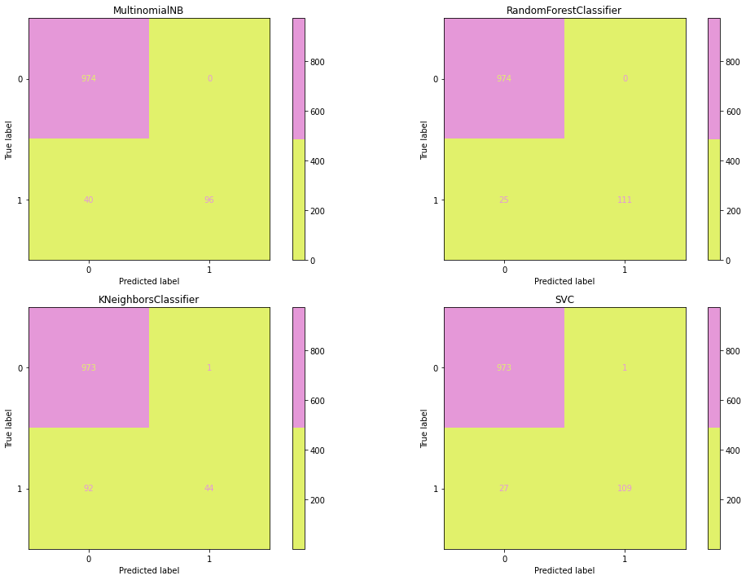

```python
cmap = ListedColormap(["#E1F16B", "#E598D8"])
fig, axes = plt.subplots(nrows=2, ncols=2, figsize=(15,10))

for cls, ax in zip(classifiers, axes.flatten()):
    plot_confusion_matrix(cls,
                          X_test,
                          y_test,
                          ax=ax,
                          cmap= cmap,
                          )
    ax.title.set_text(type(cls).__name__)
plt.tight_layout()
plt.show()
```